# Assignment 3: Model comparison

Marton Kovacs/Zoltan Kekecs

In this lab assignment you are going to work with (simulated) data related to perioperative pain and its psychological and hormonal predictors. In the assignment you will assess the added benefit of including some psychological and hormonal predictors to the already established demographic predictors of pain.

In this assignment you will set up a hierarchical regression model to predict postoperative pain after wisdom tooth surgery.

# Research problem

The amount of pain experienced around and after surgeries are highly variable between and within individuals. In order to improve surgical pain management regimens we need to understand what influences pain around surgical procedures and predict the amount of pain an individual will experience.

Your first study in this area is related to assessing the influence of trait and state psychological measures on pain, and to see whether taking into account these variables can improve our understanding of postoperative pain.

# Procedures and measures

Use the data file called ‘assignment_3_dataset’, from the ‘data/’ folder.

You have collected data from 160 adults who were scheduled to undergo surgical extraction of the third mandibular molar (wisdom tooth surgery). Patients filled out a form in the waiting room before their surgery. The form contained questions about their sex, age, and weight, and psychological questionnaires assessing anxiety, pain catastrophizing, and mindfulness (see descriptions below). You also got blood samples and saliva samples from participants in the waiting room 5 minutes before their operations to determine the serum (a component of the blood) and salivary cortisol levels of participants. Participants were contacted 5 hours after the surgery to see how much pain they were experiencing. The **level of pain** at that moment was recorded using a numerical rating scale using a **scale of 0 to 10**, where 0 means “no pain” and 10 means “worst pain I can imagine”.

**The State Trait Anxiety Inventory:** T measures trait anxiety on a scale of 20 to 80, higher scores mean higher anxiety. Anxiety has been found in many studies to positively correlate with the level of pain experienced. This is **variable STAI_trait** in the dataset.

**The Pain Catastrophizing Scale** measures the extent of pain catastrophizing, which is characterized by a tendency to magnify the threat value of a pain stimulus and to feel helpless in the presence of pain, as well as by a relative inability to prevent or inhibit pain-related thoughts in anticipation of, during, or following a painful event. The total score on this scale ranges from 0 to 52, higher scores mean higher catastrophizing. Pain catastrophizing is one of the well-established predictors of clinical pain. This is **variable pain_cat** in the dataset.

**The Mindful Attention Awareness Scale (MAAS)** measures dispositional mindfulness, which may be described as a tendency to turn attention to present-moment experiences in an open, non-judgmental way. The MAAS total score ranges from 1 to 6 (an average of the item scores), with higher scores representing higher dispositional mindfulness. Trait mindfulness has been theorized to serve as a protective factor against pain, as the individual would be more objective about their pain experience and tend to associate less discomfort, despair, and hopelessness to the pain-related sensations. This is **variable mindfulness** in the dataset.

**Cortisol** is a stress hormone associated with acute and chronic stress. Cortisol levels are thought to be positively associated with pain experience. Cortisol can be **measured from both blood and the saliva**, although, serum cortisol is often regarded in medical research as more reliably related to stress (serum is a component of the blood plasma). These are **variables cortisol_serum**, and **cortisol_saliva** in the dataset.

# Research question

Previous studies and meta-analyses showed that age and sex are often predictors of pain (age is negatively associated with pain, while sex is a predictor more dependent on the type of the procedure). You would like to determine the extent to which taking into account psychological and hormonal variables aside from the already used demographic variables would improve our understanding of postoperative pain.

To answer this research question you will **need to compare two models** (with a hierarchical regression). The **simpler model** should contain **age and sex as predictors of pain**, while the **more complex model** should contain the **predictors: age, sex, STAI, pain catastrophizing, mindfulness, and cortisol measures**. Notice that the predictors used in the simpler model are a subset of the predictors used in more complex model. **You will have to do model comparison to assess whether substantial new information was gained about pain in the more complex model compared to the simpler model.**

# What to report

As usual, before you can interpret your model, you will need to run data and model diagnostics. First, check the variables included in the more complex model (age, sex, STAI, pain catastrophizing, mindfulness, and cortisol measures as predictors, and pain as an outcome) for **coding errors**, and the model itself for **influential outliers** (for example using Cook’s distance). Furthermore, check the final model to see if the **assumptions of linear regression hold true**, that is, **normality** (of the residuals), **linearity** (of the relationship), **homogeneity of variance** (also called homoscedasticity) and that there is no excess **multicollinearity** (“uncorrelated predictors” in Navarro’s words). If you find anything amiss during these checks, make the appropriate decision or correction and report your findings and actions in your report.

**Note:** If you do any changes, such as exclude cases, or exclude predictors from the model, you will have to re-run the above checks for your final data and model.

Report the results of the simpler model and the more complex model. For both models you should report the model test statistics (adj.R2, F, df, and p value). Also, report the statistics describing the coefficients of the predictors in a table format (unstandardized regression coefficients and 95% confidence intervals, standardized regression coefficients (B and Beta values), and p values).

Write up the regression equation of the more complex model in the form of 𝑌 = 𝑏0 + 𝑏1 ∗ X1 + 𝑏2 ∗ X2 +…+ bn * Xn, in which you use the actual regression coefficients of your models. (b0 stands for the intercept and b1, b2 … bn stand for the model coefficients for each of the predictors, and X1, X2, … Xn denote the predictors).

Compare the two models in terms of how much variance they explain of pain’s variability in the sample. Report Akaike information criterion (AIC) for both models and the F test statistic and p value of the likelihood ratio test comparing the two models.

# What to discuss

In your discussion of the findings, briefly interpret the results of the above analyses, and indicate whether you think that anything was gained by including the psychological and hormone measures in the model.

# Solution

## Read the data

Read the dataset used in this assignment. Pay attention to the extension of the datafile.

```r
knitr::opts_chunk$set(echo = TRUE)
library(tidyverse)
library(broom)
library(ggfortify)
library(car)
library(lmtest)
library(AICcmodavg)

assignment_3_dataset <- readxl::read_excel("C:/Users/flora/OneDrive/Dokumentumok/GitHub/elte-ppk-r-course-r_data_analysis-23_24_1/assignment_3_dataset.xls")
```

## Data and model diagnostics

### Data diagnostics

#### Descriptives of the variables

Run an exploratory data analysis (EDA) to investigate the dataset.

```r
head(assignment_3_dataset)
```

```
## # A tibble: 6 × 12
##   ID     pain sex      age STAI_trait pain_cat cortisol_serum cortisol_saliva
##   <chr> <dbl> <chr>  <dbl>      <dbl>    <dbl>          <dbl>           <dbl>
## 1 ID_1      5 female    38         39       25           4.67            4.78
## 2 ID_2      4 female    36         46       31           6.01            6.71
## 3 ID_3      5 female    51         49       32           5.18            4.75
## 4 ID_4      7 female    39         48       41           6.65            6.68
## 5 ID_5      4 male      48         36       26           2.95            3.2
## 6 ID_6      6 female    45         37       28           4.32            4.36
## # ℹ 4 more variables: mindfulness <dbl>, weight <dbl>, IQ <dbl>,
## #   household_income <dbl>
```

```r
summary(assignment_3_dataset)
```

```
##       ID                 pain            sex                 age
##  Length:160         Min.   : 1.000   Length:160         Min.   :24.00
##  Class :character   1st Qu.: 4.000   Class :character   1st Qu.:38.00
##  Mode  :character   Median : 5.000   Mode  :character   Median :41.00
##                     Mean   : 5.194                      Mean   :40.74
##                     3rd Qu.: 6.000                      3rd Qu.:44.00
##                     Max.   :50.000                      Max.   :53.00
##    STAI_trait       pain_cat     cortisol_serum  cortisol_saliva
##  Min.   :26.00   Min.   :14.00   Min.   :2.700   Min.   :2.530
##  1st Qu.:37.00   1st Qu.:27.00   1st Qu.:4.268   1st Qu.:4.120
##  Median :40.00   Median :30.00   Median :4.995   Median :5.035
##  Mean   :40.09   Mean   :29.88   Mean   :4.941   Mean   :4.952
##  3rd Qu.:43.00   3rd Qu.:32.25   3rd Qu.:5.633   3rd Qu.:5.753
##  Max.   :52.00   Max.   :42.00   Max.   :7.110   Max.   :7.190
##   mindfulness        weight            IQ         household_income
##  Min.   :1.000   Min.   :33.80   Min.   : 52.00   Min.   :  5548
##  1st Qu.:2.595   1st Qu.:62.15   1st Qu.: 91.75   1st Qu.: 53489
##  Median :3.115   Median :68.77   Median :101.00   Median : 72149
##  Mean   :3.204   Mean   :68.57   Mean   :100.74   Mean   : 70426
##  3rd Qu.:3.830   3rd Qu.:74.65   3rd Qu.:109.00   3rd Qu.: 87734
##  Max.   :6.220   Max.   :97.13   Max.   :144.00   Max.   :139268
```

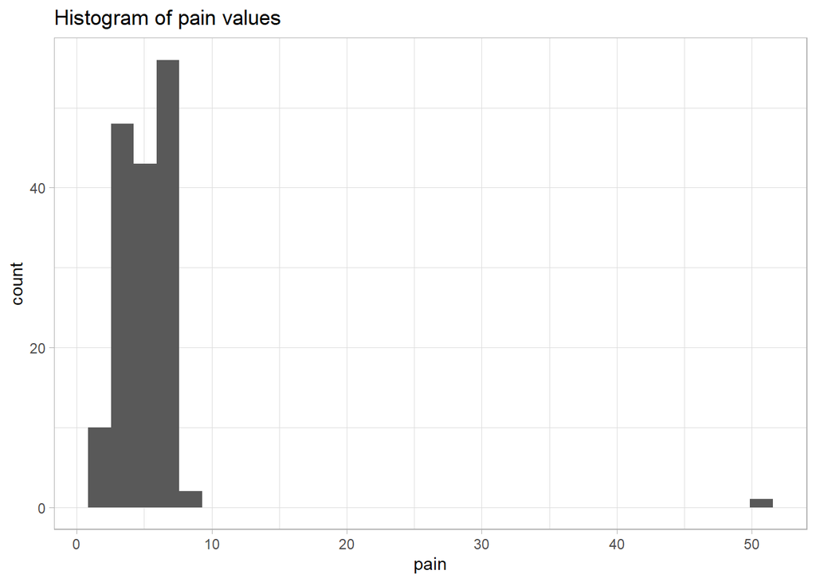

```r
theme_set(theme_light())

ggplot(assignment_3_dataset, aes(pain)) +
  geom_histogram() +
  labs(title = "Histogram of pain values")
```

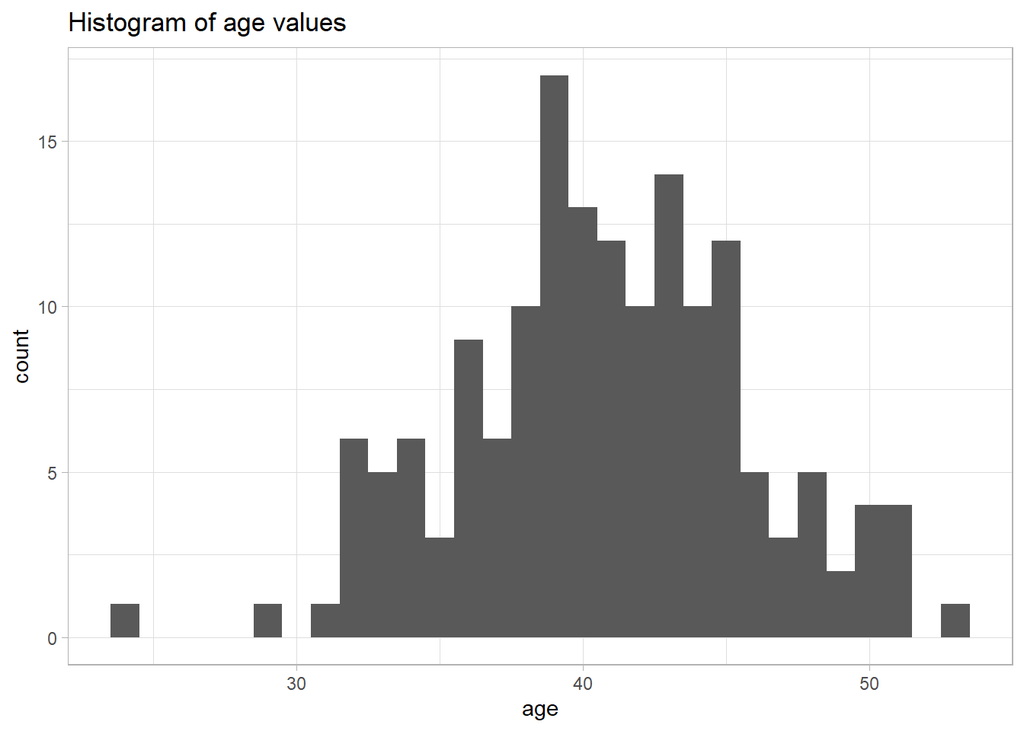

```r
ggplot(assignment_3_dataset, aes(age)) +
  geom_histogram() +
  labs(title = "Histogram of age values")
```

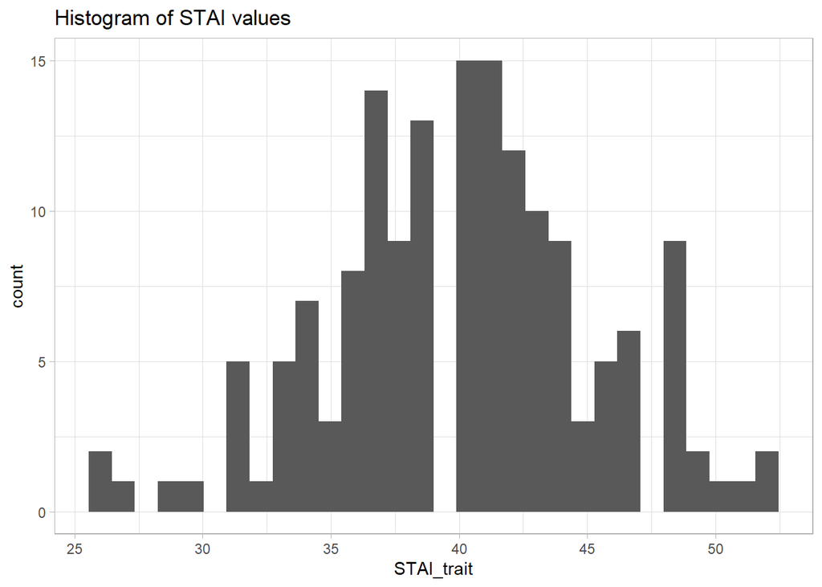

```r
ggplot(assignment_3_dataset, aes(STAI_trait)) +
  geom_histogram() +
  labs(title = "Histogram of STAI values")
```

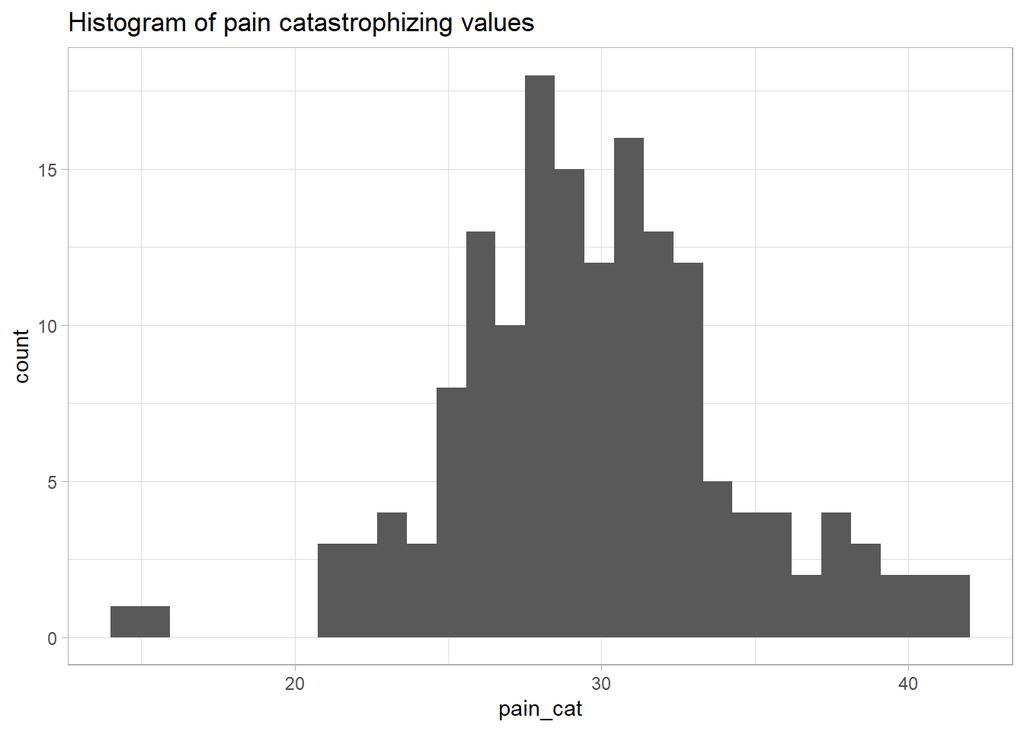

```r
ggplot(assignment_3_dataset, aes(pain_cat)) +
  geom_histogram() +
  labs(title = "Histogram of pain catastrophizing values")
```

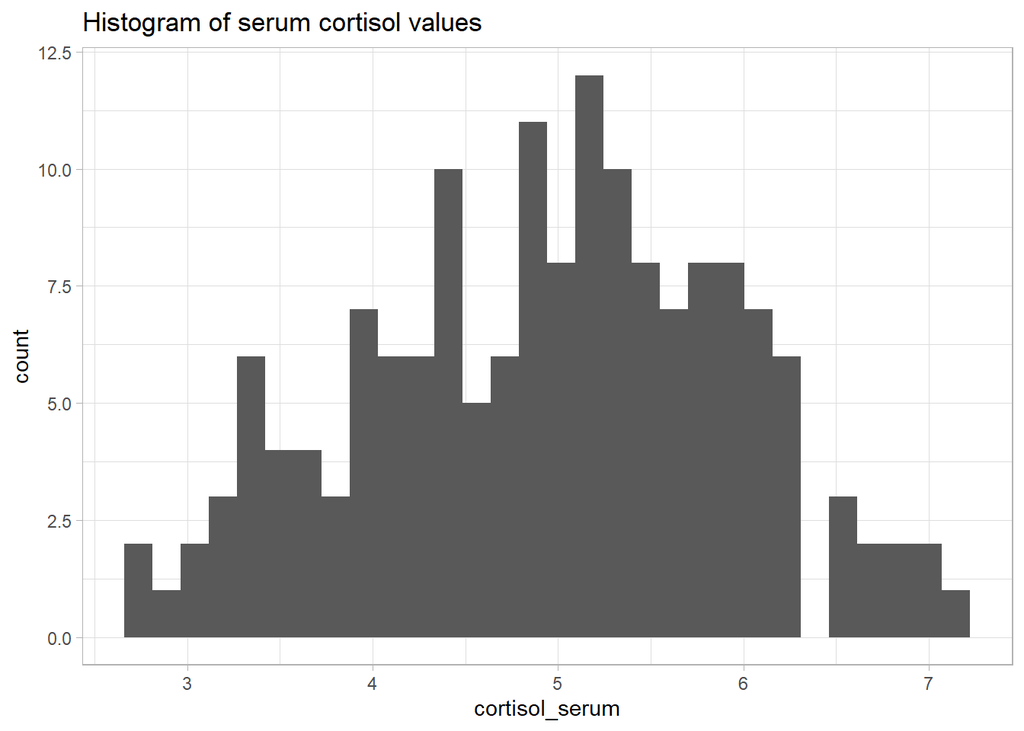

```r
ggplot(assignment_3_dataset, aes(cortisol_serum)) +
  geom_histogram() +
  labs(title = "Histogram of serum cortisol values")
```

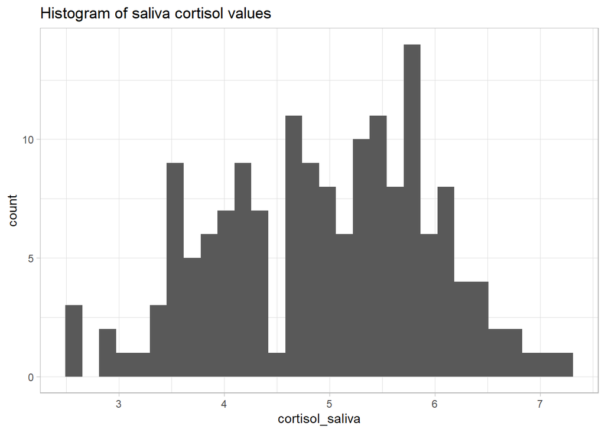

```r
ggplot(assignment_3_dataset, aes(cortisol_saliva)) +
  geom_histogram() +
  labs(title = "Histogram of saliva cortisol values")
```

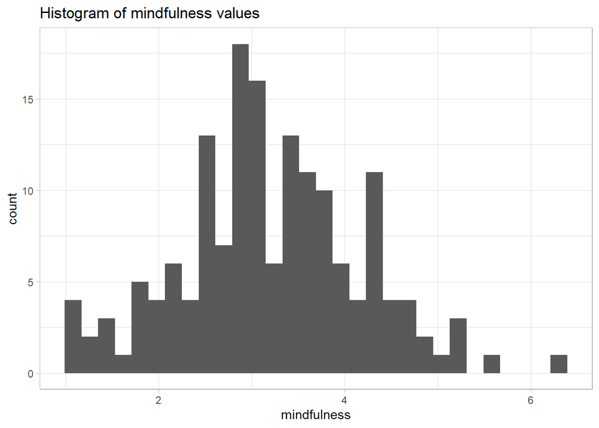

```r
ggplot(assignment_3_dataset, aes(mindfulness)) +
  geom_histogram() +
  labs(title = "Histogram of mindfulness values")
```

```r
assignment_3_dataset %>%
  count(sex)
```

```
## # A tibble: 3 × 2
##   sex        n
##   <chr>  <int>
## 1 female    83
## 2 male      76
## 3 woman      1
```

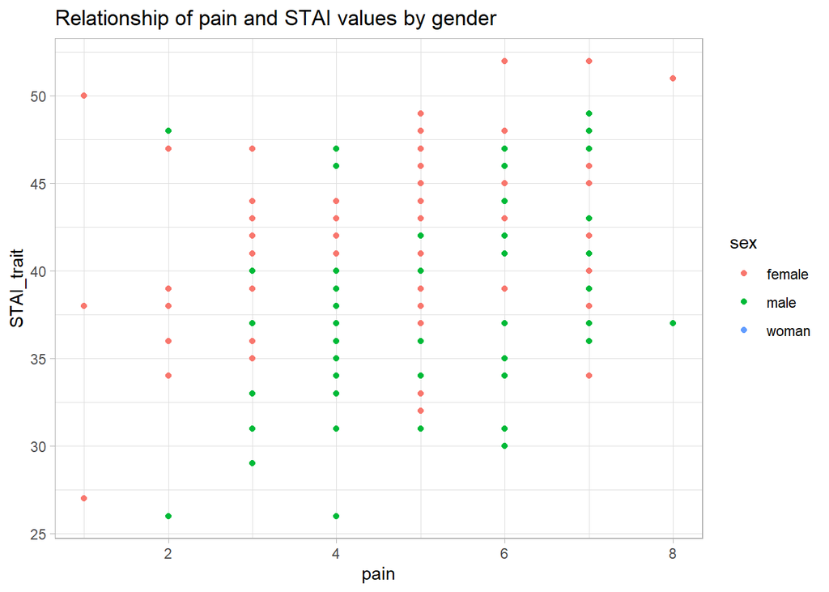

```r
assignment_3_dataset %>%
  filter(pain < 50) %>%
  ggplot(aes(pain, STAI_trait, color = sex)) +
  geom_point() +
  labs(title = "Relationship of pain and STAI values by gender")
```

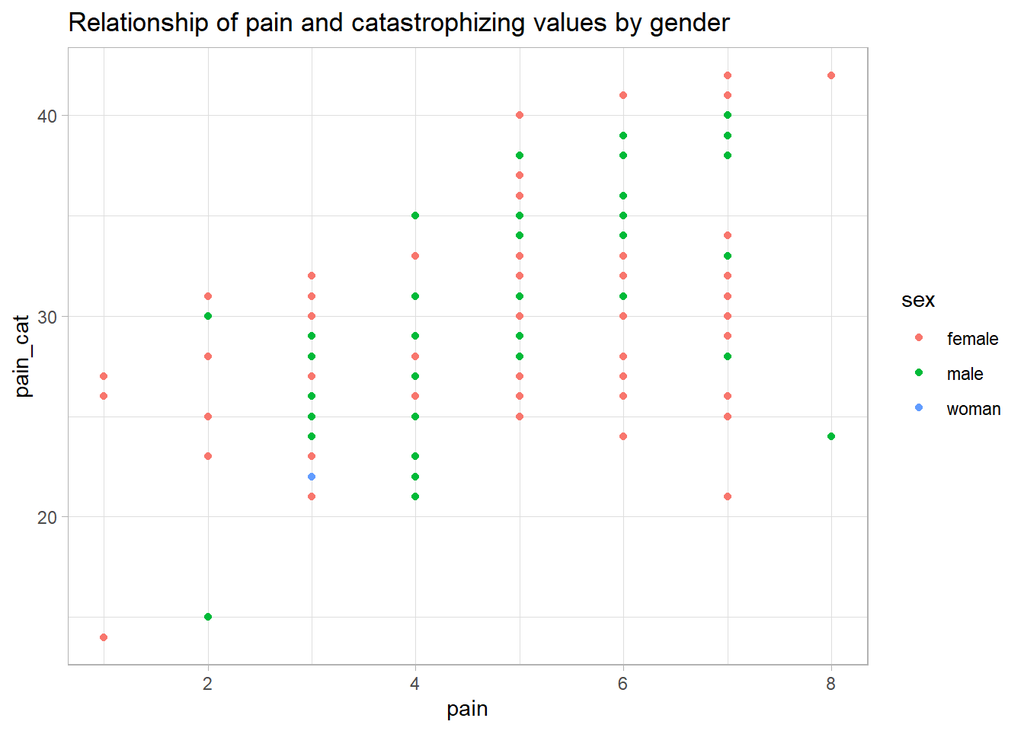

```r
assignment_3_dataset %>%
  filter(pain < 50) %>%
  ggplot(aes(pain, pain_cat, color = sex)) +
  geom_point() +
  labs(title = "Relationship of pain and catastrophizing values by gender")
```

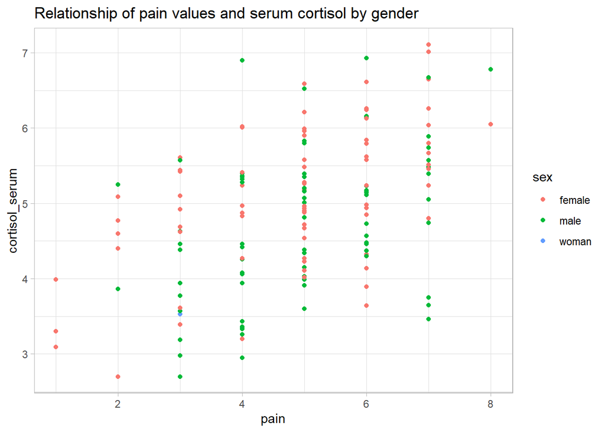

```r
assignment_3_dataset %>%
  filter(pain < 50) %>%
  ggplot(aes(pain, cortisol_serum, color = sex)) +
  geom_point() +
  labs(title = "Relationship of pain values and serum cortisol by gender")
```

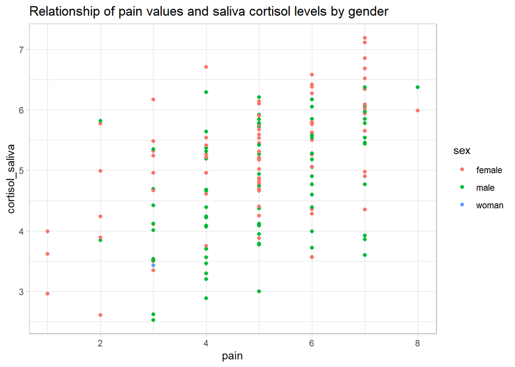

```r
assignment_3_dataset %>%
  filter(pain < 50) %>%
  ggplot(aes(pain, cortisol_saliva, color = sex)) +
  geom_point() +
  labs(title = "Relationship of pain values and saliva cortisol levels by gender")
```

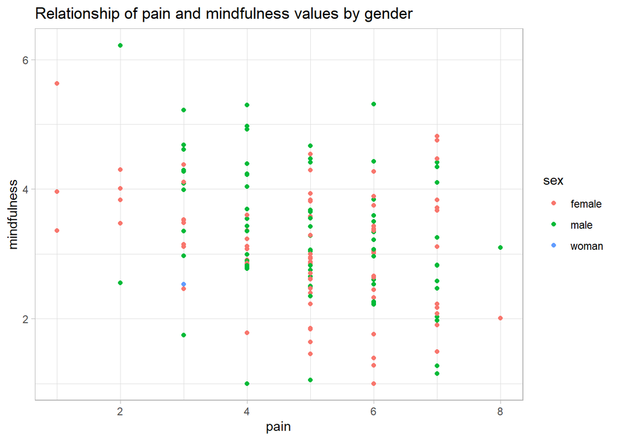

```r
assignment_3_dataset %>%
  filter(pain < 50) %>%
  ggplot(aes(pain, mindfulness, color = sex)) +
  geom_point() +
  labs(title = "Relationship of pain and mindfulness values by gender")
```

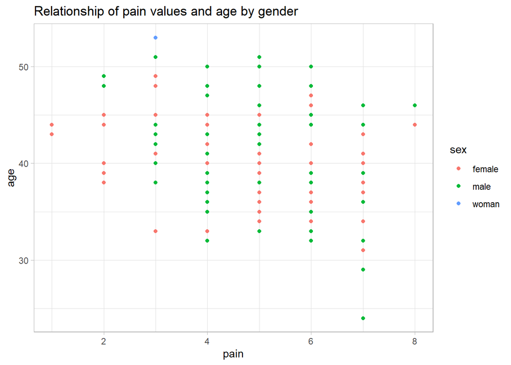

```r
assignment_3_dataset %>%
  filter(pain < 50) %>%
  ggplot(aes(pain, age, color = sex)) +
  geom_point() +
  labs(title = "Relationship of pain values and age by gender")
```

```r
round(cor(assignment_3_dataset[c('pain', 'STAI_trait', 'pain_cat', 'cortisol_serum', 'cortisol_saliva', 'mindfulness')]), 2)
```

```
##                  pain STAI_trait pain_cat cortisol_serum cortisol_saliva
## pain             1.00       0.15     0.19           0.26            0.28
## STAI_trait       0.15       1.00     0.47           0.45            0.49
## pain_cat         0.19       0.47     1.00           0.41            0.37
## cortisol_serum   0.26       0.45     0.41           1.00            0.91
## cortisol_saliva  0.28       0.49     0.37           0.91            1.00
## mindfulness     -0.11      -0.48    -0.50          -0.33           -0.33
##                 mindfulness
## pain                  -0.11
## STAI_trait            -0.48
## pain_cat              -0.50
## cortisol_serum        -0.33
## cortisol_saliva       -0.33
## mindfulness            1.00
```

```r
sapply(assignment_3_dataset, function(x) sum(is.na(x)))
```

```
##               ID             pain              sex              age
##                0                0                0                0
##       STAI_trait         pain_cat   cortisol_serum  cortisol_saliva
##                0                0                0                0
##      mindfulness           weight               IQ household_income
##                0                0                0                0
```

```r
Q1 <- quantile(assignment_3_dataset$pain, 0.25)
Q3 <- quantile(assignment_3_dataset$pain, 0.75)
IQR <- Q3 - Q1

outliers_pain <- subset(assignment_3_dataset, assignment_3_dataset$pain < (Q1 - 1.5*IQR) | assignment_3_dataset$pain > (Q3 + 1.5*IQR))

outliers_pain
```

```
## # A tibble: 1 × 12
##   ID      pain sex      age STAI_trait pain_cat cortisol_serum cortisol_saliva
##   <chr>  <dbl> <chr>  <dbl>      <dbl>    <dbl>          <dbl>           <dbl>
## 1 ID_142    50 female    41         44       30           5.85            6.14
## # ℹ 4 more variables: mindfulness <dbl>, weight <dbl>, IQ <dbl>,
## #   household_income <dbl>
```

```r
Q1 <- quantile(assignment_3_dataset$age, 0.25)
Q3 <- quantile(assignment_3_dataset$age, 0.75)
IQR <- Q3 - Q1

outliers_age <- subset(assignment_3_dataset, assignment_3_dataset$age < (Q1 - 1.5*IQR) | assignment_3_dataset$pain > (Q3 + 1.5*IQR))

outliers_age
```

```
## # A tibble: 1 × 12
##   ID      pain sex     age STAI_trait pain_cat cortisol_serum cortisol_saliva
##   <chr>  <dbl> <chr> <dbl>      <dbl>    <dbl>          <dbl>           <dbl>
## 1 ID_135     7 male     24         40       38           5.05            5.85
## # ℹ 4 more variables: mindfulness <dbl>, weight <dbl>, IQ <dbl>,
## #   household_income <dbl>
```

```r
Q1 <- quantile(assignment_3_dataset$pain_cat, 0.25)
Q3 <- quantile(assignment_3_dataset$pain_cat, 0.75)
IQR <- Q3 - Q1

outliers_paincat <- subset(assignment_3_dataset, assignment_3_dataset$pain_cat < (Q1 - 1.5*IQR) | assignment_3_dataset$pain_cat > (Q3 + 1.5*IQR))

outliers_paincat
```

```
## # A tibble: 6 × 12
##   ID      pain sex      age STAI_trait pain_cat cortisol_serum cortisol_saliva
##   <chr>  <dbl> <chr>  <dbl>      <dbl>    <dbl>          <dbl>           <dbl>
## 1 ID_4       7 female    39         48       41           6.65            6.68
## 2 ID_32      1 female    43         27       14           3.09            2.96
## 3 ID_34      6 female    38         48       41           6.24            5.78
## 4 ID_49      2 male      49         26       15           3.86            3.85
## 5 ID_102     8 female    44         51       42           6.05            5.99
## 6 ID_113     7 female    41         52       42           7.11            7.11
## # ℹ 4 more variables: mindfulness <dbl>, weight <dbl>, IQ <dbl>,
## #   household_income <dbl>
```

#### Correct coding errors

If you find values in the dataset during the EDA, that are not correct based on the provided descriptions of the variables of the dataset please correct them here.

```r
pain_df_recoded <- assignment_3_dataset %>%
  mutate(sex = fct_recode(sex, "female" = "woman"))

levels(pain_df_recoded$sex)
```

```
## [1] "female" "male"
```

```r
pain_df <- pain_df_recoded %>%
  filter(pain < 50)

summary(pain_df)
```

```
##       ID                 pain           sex          age          STAI_trait
##  Length:159         Min.   :1.000   female:83   Min.   :24.00   Min.   :26.00
##  Class :character   1st Qu.:4.000   male  :76   1st Qu.:38.00   1st Qu.:37.00
##  Mode  :character   Median :5.000               Median :41.00   Median :40.00
##                     Mean   :4.912               Mean   :40.74   Mean   :40.07
##                     3rd Qu.:6.000               3rd Qu.:44.00   3rd Qu.:43.00
##                     Max.   :8.000               Max.   :53.00   Max.   :52.00
##     pain_cat     cortisol_serum  cortisol_saliva  mindfulness
##  Min.   :14.00   Min.   :2.700   Min.   :2.530   Min.   :1.000
##  1st Qu.:27.00   1st Qu.:4.265   1st Qu.:4.120   1st Qu.:2.590
##  Median :30.00   Median :4.980   Median :5.020   Median :3.110
##  Mean   :29.87   Mean   :4.936   Mean   :4.945   Mean   :3.204
##  3rd Qu.:32.50   3rd Qu.:5.615   3rd Qu.:5.740   3rd Qu.:3.830
##  Max.   :42.00   Max.   :7.110   Max.   :7.190   Max.   :6.220
##      weight            IQ        household_income
##  Min.   :33.80   Min.   : 52.0   Min.   :  5548
##  1st Qu.:62.15   1st Qu.: 91.5   1st Qu.: 53364
##  Median :68.75   Median :101.0   Median : 72111
##  Mean   :68.54   Mean   :100.6   Mean   : 70402
##  3rd Qu.:74.72   3rd Qu.:108.5   3rd Qu.: 87887
##  Max.   :97.13   Max.   :144.0   Max.   :139268
```

```r
data <- pain_df[ , c("age", "pain", "sex", "STAI_trait", "pain_cat", "cortisol_serum", "cortisol_saliva", "mindfulness")]
```

### Model diagnostics

#### Build the more complex model

In order to test the more complex model for outliers and to test the assumptions first build the model.

```r
model_c <- lm(pain ~ age + sex + STAI_trait + pain_cat + cortisol_serum + cortisol_saliva + mindfulness, data = data)
glance(model_c)
```

```
## # A tibble: 1 × 12
##   r.squared adj.r.squared sigma statistic  p.value    df logLik   AIC   BIC
##       <dbl>         <dbl> <dbl>     <dbl>    <dbl> <dbl>  <dbl> <dbl> <dbl>
## 1     0.365         0.335  1.24      12.4 1.77e-12     7  -256.  530.  558.
## # ℹ 3 more variables: deviance <dbl>, df.residual <int>, nobs <int>
```

```r
summary(model_c)
```

```
##
## Call:
## lm(formula = pain ~ age + sex + STAI_trait + pain_cat + cortisol_serum +
##     cortisol_saliva + mindfulness, data = data)
##
## Residuals:
##     Min      1Q  Median      3Q     Max
## -3.2331 -0.7638 -0.0435  0.7736  2.9558
##
## Coefficients:
##                 Estimate Std. Error t value Pr(>|t|)
## (Intercept)      1.35209    1.72405   0.784  0.43412
## age             -0.02395    0.02413  -0.992  0.32256
## sexmale          0.31689    0.21061   1.505  0.13451
## STAI_trait      -0.02554    0.02788  -0.916  0.36119
## pain_cat         0.09491    0.02878   3.298  0.00122 **
## cortisol_serum   0.16662    0.24529   0.679  0.49801
## cortisol_saliva  0.43773    0.25209   1.736  0.08452 .
## mindfulness     -0.12942    0.12474  -1.038  0.30114
## ---
## Signif. codes:  0 '***' 0.001 '**' 0.01 '*' 0.05 '.' 0.1 ' ' 1
##
## Residual standard error: 1.242 on 151 degrees of freedom
## Multiple R-squared:  0.3648, Adjusted R-squared:  0.3354
## F-statistic: 12.39 on 7 and 151 DF,  p-value: 1.768e-12
```

#### Checking for influential outliers

Check for outlier values in the model.

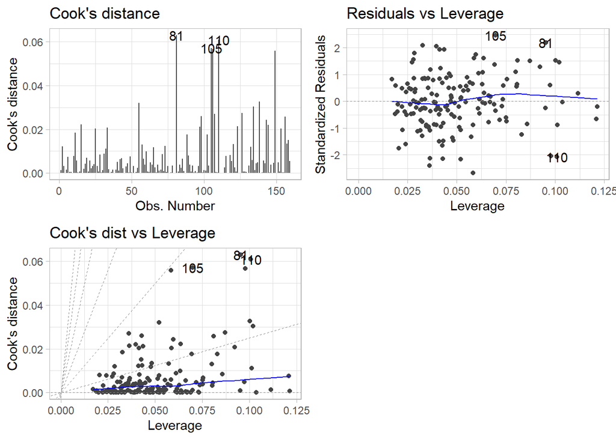

```r
autoplot(model_c, which = 4:6)
```

```r
CooksD <- cooks.distance(model_c)
influential <- CooksD[(CooksD > (3 * mean(CooksD, na.rm = TRUE)))]
influential
```

```
##         15         55         81         98        105        106        107
## 0.02217591 0.03201338 0.06294923 0.02586085 0.05712480 0.05663562 0.02702243
##        110        126        134        138        143        144        149
## 0.06071656 0.02736447 0.03033198 0.03261319 0.02429702 0.02191969 0.05572854
##        156
## 0.02573158
```

#### Checking assumptions

Check the normality assumption.

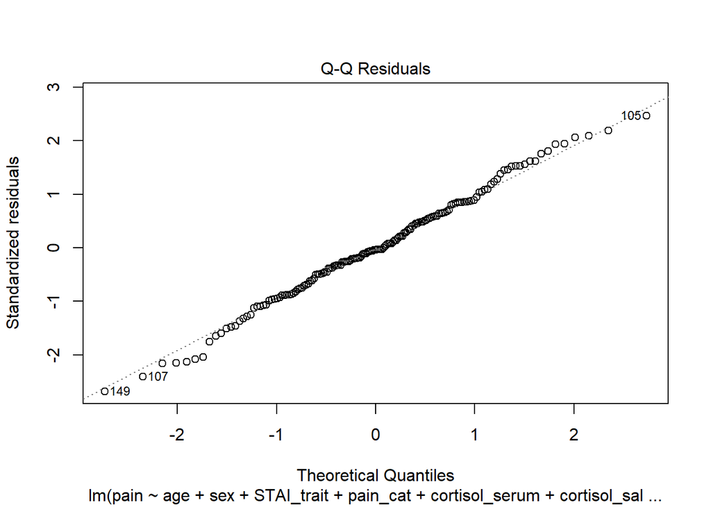

```r
plot(model_c, 2)
```

Check the linearity assumption.

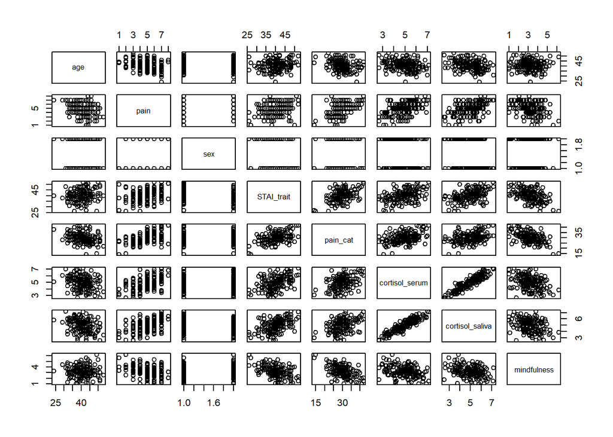

```r
pairs(data)
```

Check the homoscedasticty assumption (homogeneity of variance).

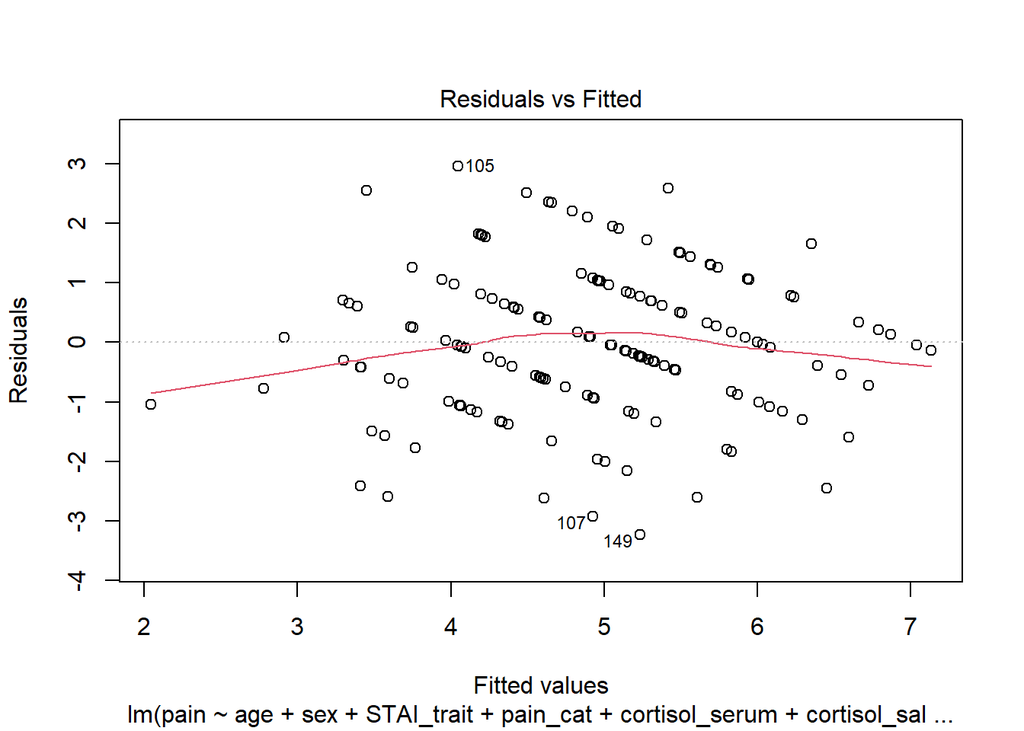

```r
plot(model_c, 1)
```

Check the multicollinearity assumption.

(VIF above 5), or a VIF threshold of 3 is recommended in this paper: http://onlinelibrary.wiley.com/doi/10.1111/j.2041-210X.2009.00001.x/full

Some info about VIF: https://statisticalhorizons.com/multicollinearity http://blog.minitab.com/blog/understanding-statistics/handling-multicollinearity-in-regression-analysis

```r
vif(model_c)
```

```
##             age             sex      STAI_trait        pain_cat  cortisol_serum
##        1.526619        1.140617        2.117744        1.948680        6.065266
## cortisol_saliva     mindfulness
##        6.622923        1.530694
```

### Making decision based on model diagnostics

If based on the assumption tests you decide to drop a predictor variable you should do that here. Create your updated model.

```r
data2 <- pain_df[ , c("age", "pain", "sex", "STAI_trait", "pain_cat", "cortisol_serum", "mindfulness")]

model_2 <- lm(pain ~ age + sex + STAI_trait + pain_cat + cortisol_serum + mindfulness, data = data2)
summary(model_2)
```

```
##
## Call:
## lm(formula = pain ~ age + sex + STAI_trait + pain_cat + cortisol_serum +
##     mindfulness, data = data2)
##
## Residuals:
##      Min       1Q   Median       3Q      Max
## -2.99823 -0.79580 -0.00686  0.79647  2.65278
##
## Coefficients:
##                Estimate Std. Error t value Pr(>|t|)
## (Intercept)     1.97850    1.69702   1.166  0.24550
## age            -0.03592    0.02328  -1.543  0.12486
## sexmale         0.31090    0.21197   1.467  0.14452
## STAI_trait     -0.01130    0.02683  -0.421  0.67421
## pain_cat        0.08459    0.02835   2.984  0.00331 **
## cortisol_serum  0.53519    0.12376   4.324 2.76e-05 ***
## mindfulness    -0.14588    0.12520  -1.165  0.24576
## ---
## Signif. codes:  0 '***' 0.001 '**' 0.01 '*' 0.05 '.' 0.1 ' ' 1
##
## Residual standard error: 1.25 on 152 degrees of freedom
## Multiple R-squared:  0.3521, Adjusted R-squared:  0.3265
## F-statistic: 13.77 on 6 and 152 DF,  p-value: 1.841e-12
```

#### Checking outliers of the updated model

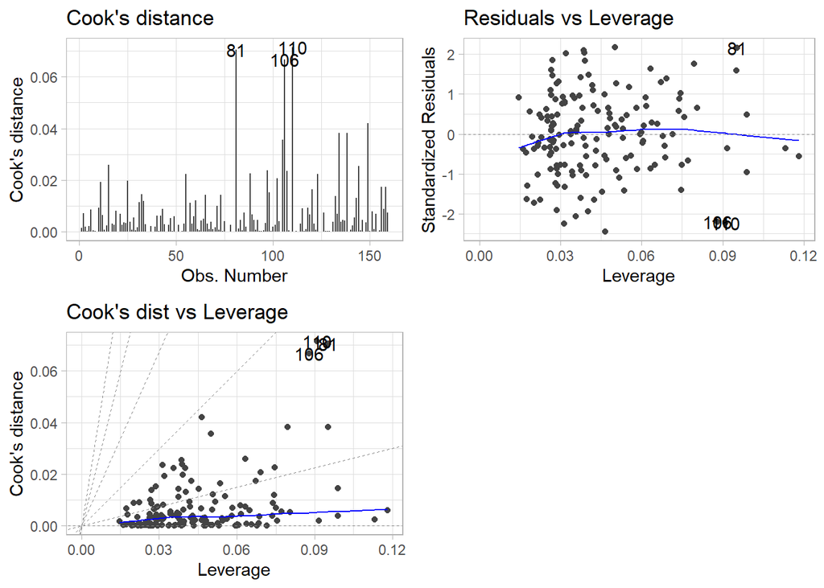

```r
autoplot(model_2, which = 4:6)
```

```r
CooksD2 <- cooks.distance(model_2)
influential <- CooksD2[(CooksD2 > (3 * mean(CooksD2, na.rm = TRUE)))]
influential
```

```
##         15         55         81         88         97        105        106
## 0.02585445 0.02246434 0.07052220 0.02255262 0.02381242 0.03570024 0.06663020
##        107        110        123        134        138        144        149
## 0.02358516 0.07145524 0.02234401 0.03829138 0.03830986 0.02537668 0.04200902
```

#### Checking assumptions of the updated model

Normality assumption

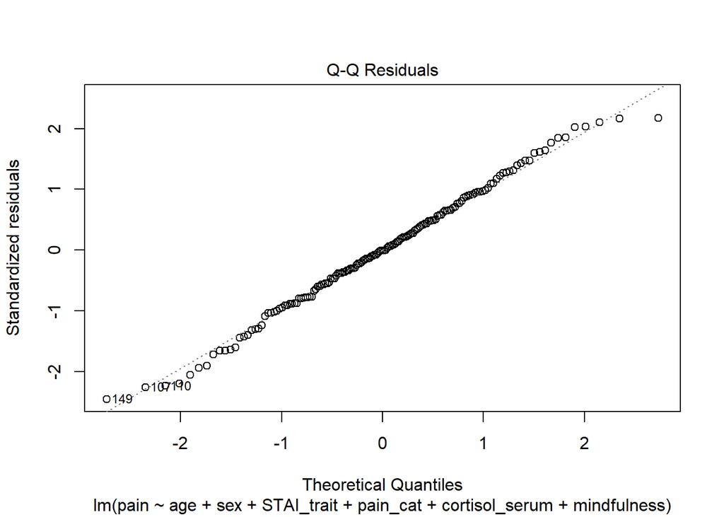

```r
plot(model_2, 2)
```

Linearity assumption

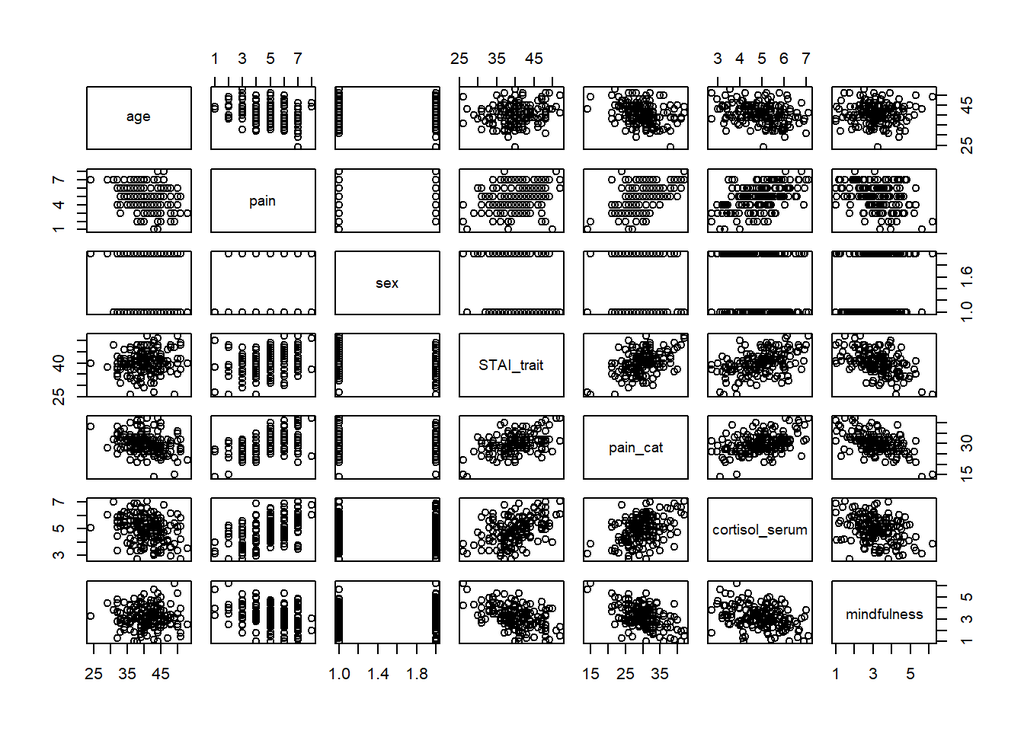

```r
pairs(data2)
```

Homoscedasticty assumption (homogeneity of variance)

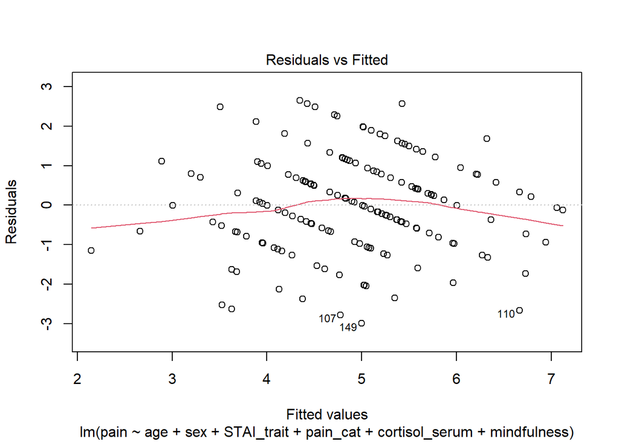

```r
plot(model_2, 1)
```

Multicollinearity assumption

```r
vif(model_2)
```

```
##            age            sex     STAI_trait       pain_cat cortisol_serum
##       1.401982       1.140312       1.934597       1.865680       1.523830
##    mindfulness
##       1.521854
```

## Model comparison

Create the simple model and get the results of the model that needs to be reported based on the What to report section.

```r
model_simple <- lm(pain ~ age + sex, data = pain_df)
summary(model_simple)
```

```
##
## Call:
## lm(formula = pain ~ age + sex, data = pain_df)
##
## Residuals:
##     Min      1Q  Median      3Q     Max
## -3.6617 -0.9974  0.1464  1.0508  3.5026
##
## Coefficients:
##             Estimate Std. Error t value Pr(>|t|)
## (Intercept)  8.49145    0.94828   8.955 9.64e-16 ***
## age         -0.08906    0.02304  -3.865 0.000163 ***
## sexmale      0.10287    0.23268   0.442 0.659028
## ---
## Signif. codes:  0 '***' 0.001 '**' 0.01 '*' 0.05 '.' 0.1 ' ' 1
##
## Residual standard error: 1.464 on 156 degrees of freedom
## Multiple R-squared:  0.08784,    Adjusted R-squared:  0.07614
## F-statistic: 7.511 on 2 and 156 DF,  p-value: 0.0007684
```

Create the more complex model based on the results of the model diagnostics. Also, get the results that needs to be reported based on the What to report section.

```r
model_complex <- lm(pain ~ age + sex + STAI_trait + pain_cat + cortisol_serum + mindfulness, data = data2)
summary(model_complex)
```

```
##
## Call:
## lm(formula = pain ~ age + sex + STAI_trait + pain_cat + cortisol_serum +
##     mindfulness, data = data2)
##
## Residuals:
##      Min       1Q   Median       3Q      Max
## -2.99823 -0.79580 -0.00686  0.79647  2.65278
##
## Coefficients:
##                Estimate Std. Error t value Pr(>|t|)
## (Intercept)     1.97850    1.69702   1.166  0.24550
## age            -0.03592    0.02328  -1.543  0.12486
## sexmale         0.31090    0.21197   1.467  0.14452
## STAI_trait     -0.01130    0.02683  -0.421  0.67421
## pain_cat        0.08459    0.02835   2.984  0.00331 **
## cortisol_serum  0.53519    0.12376   4.324 2.76e-05 ***
## mindfulness    -0.14588    0.12520  -1.165  0.24576
## ---
## Signif. codes:  0 '***' 0.001 '**' 0.01 '*' 0.05 '.' 0.1 ' ' 1
##
## Residual standard error: 1.25 on 152 degrees of freedom
## Multiple R-squared:  0.3521, Adjusted R-squared:  0.3265
## F-statistic: 13.77 on 6 and 152 DF,  p-value: 1.841e-12
```

```r
confint(model_complex)
```

```
##                      2.5 %     97.5 %
## (Intercept)    -1.37430028 5.33129361
## age            -0.08191580 0.01006816
## sexmale        -0.10789244 0.72970240
## STAI_trait     -0.06430148 0.04170302
## pain_cat        0.02858705 0.14059932
## cortisol_serum  0.29067129 0.77970691
## mindfulness    -0.39323698 0.10147335
```

```r
tidy(model_complex)
```

```
## # A tibble: 7 × 5
##   term           estimate std.error statistic   p.value
##   <chr>             <dbl>     <dbl>     <dbl>     <dbl>
## 1 (Intercept)      1.98      1.70       1.17  0.245
## 2 age             -0.0359    0.0233    -1.54  0.125
## 3 sexmale          0.311     0.212      1.47  0.145
## 4 STAI_trait      -0.0113    0.0268    -0.421 0.674
## 5 pain_cat         0.0846    0.0283     2.98  0.00331
## 6 cortisol_serum   0.535     0.124      4.32  0.0000276
## 7 mindfulness     -0.146     0.125     -1.17  0.246
```

```r
model_complex_std <- lm(scale(pain) ~ scale(age) + sex + scale(STAI_trait) + scale(pain_cat) + scale(cortisol_serum) + scale(mindfulness), data = data2)
summary(model_complex_std)
```

```
##
## Call:
## lm(formula = scale(pain) ~ scale(age) + sex + scale(STAI_trait) +
##     scale(pain_cat) + scale(cortisol_serum) + scale(mindfulness),
##     data = data2)
##
## Residuals:
##     Min      1Q  Median      3Q     Max
## -1.9679 -0.5223 -0.0045  0.5228  1.7411
##
## Coefficients:
##                       Estimate Std. Error t value Pr(>|t|)
## (Intercept)           -0.09754    0.09305  -1.048  0.29618
## scale(age)            -0.11929    0.07730  -1.543  0.12486
## sexmale                0.20406    0.13913   1.467  0.14452
## scale(STAI_trait)     -0.03825    0.09081  -0.421  0.67421
## scale(pain_cat)        0.26611    0.08917   2.984  0.00331 **
## scale(cortisol_serum)  0.34851    0.08059   4.324 2.76e-05 ***
## scale(mindfulness)    -0.09384    0.08054  -1.165  0.24576
## ---
## Signif. codes:  0 '***' 0.001 '**' 0.01 '*' 0.05 '.' 0.1 ' ' 1
##
## Residual standard error: 0.8206 on 152 degrees of freedom
## Multiple R-squared:  0.3521, Adjusted R-squared:  0.3265
## F-statistic: 13.77 on 6 and 152 DF,  p-value: 1.841e-12
```

Compare the two models.

```r
anova(model_simple, model_complex)
```

```
## Analysis of Variance Table
##
## Model 1: pain ~ age + sex
## Model 2: pain ~ age + sex + STAI_trait + pain_cat + cortisol_serum + mindfulness
##   Res.Df    RSS Df Sum of Sq      F    Pr(>F)
## 1    156 334.55
## 2    152 237.62  4    96.931 15.501 1.175e-10 ***
## ---
## Signif. codes:  0 '***' 0.001 '**' 0.01 '*' 0.05 '.' 0.1 ' ' 1
```

```r
lrtest(model_complex, model_simple)
```

```
## Likelihood ratio test
##
## Model 1: pain ~ age + sex + STAI_trait + pain_cat + cortisol_serum + mindfulness
## Model 2: pain ~ age + sex
##   #Df  LogLik Df  Chisq Pr(>Chisq)
## 1   8 -257.55
## 2   4 -284.75 -4 54.397  4.347e-11 ***
## ---
## Signif. codes:  0 '***' 0.001 '**' 0.01 '*' 0.05 '.' 0.1 ' ' 1
```

```r
models <- list(model_simple, model_complex)

mod.names <- c('age.sex', 'age.sex.STAI.cat.cort.mind')

aictab(cand.set = models, modnames = mod.names)
```

```
##
## Model selection based on AICc:
##
##                            K   AICc Delta_AICc AICcWt Cum.Wt      LL
## age.sex.STAI.cat.cort.mind 8 532.06        0.0      1      1 -257.55
## age.sex                    4 577.76       45.7      0      1 -284.75
```

## Report

According to the exploratory data analysis, one two coding errors were found. One, with ‘female’ reported as ‘woman’, was corrected. The other one, where the reported pain level fell out of the range of the allowed range, was the most influential outlier, therefore it was removed from the dataset.

The first model, including pain as the outcome variable and age, sex, trait STAI value, pain catastrophizing value, serum cortisol level, salivary cortisol level and mindfulness value as predictor variables, yielded a significant result (adj.R2 = 0.3354, F = 12.39, df = 151, p = 1.768e-12). However, the multicollinearity assumption was violated, with serum cortisol and salivary cortisol levels showing a high correlation (VIF = 6.065266 and VIF = 6.622923 respectively). Therefore, salivary cortisol was excluded from the final model, as one cortisol measure yielded enough predictive power.

The final model consisted of pain as the outcome variable, and age, sex, trait STAI value, pain catastrophizing value, serum cortisol level and mindfulness value as predictor variables. This model was statistically significant (adj.R2 = 0.3265, F = 13.77, df = 152, p = 1.841e-12), explaining 32.65% of the variance of reported pain levels in this sample. Pain catastrophizing had a positive, statistically significant effect on reported pain levels (unstandardized B = 0.08459, CI lower = 0.028587, CI higher = 0.1405993, standardized B = 0.26611, p = 0.00331). Serum cortisol levels also had a positive, statistically significant effect on reported pain levels (unstandardized B = 0.53519, CI lower = 0.290671, CI higher = 0.779706, standardized B = 0.34851, p = 2.76e-05).

The regression equation of the more complex model is as follows:

Pain Level = 1.97850 + -0.03592*(age) + 0.31090*(sex) + -0.01130*(trait STAI) + 0.08459*(pain catastrophizing) + 0.53519*(serum cortisol levels) + -0.14588*(minfulness).

## Discussion

According to the statistical analyses of the above data, it can be concluded that including psychological and hormonal measures to explain the variance of reported pain levels is a reasonable idea. In the complex model, pain catastrophizing and serum cortisol levels showed a statistically significant impact on pain levels, signifying that higher catastrophizing and higher cortisol levels might indicate a higher sensitivity to pain reception. Since a larger proportion of the variance of pain levels was explained by the complex model, I think substantially more predictive power was gained by using this extended model.